# Testing the assumptions of SLR and introducing new variables

## Independence assumption

One of the strongest regression assumptions is the one regarding independence. Departures from the independence assumption are often exhibited by correlation (or autocorrelation) present in the residuals. There can be positive or negative correlation.  
To check this assumption, we use the first plot and we watch out for any patterns or structure: the points should be randomly scattered on the plot.  
We can also do a test for this: se ulteriomente non siamo sicuri di questa assunzione possiamo fare un ulteriore test

```r
# install.packages("lmtest")
library(lmtest)
dwtest(cars.lm, alternative = "two.sided")
```

```
    Durbin-Watson test

data:  cars.lm
DW = 1.6762, p-value = 0.1904
alternative hypothesis: true autocorrelation is not 0
```

p>0.05 quindi confermiamo che non ci siano problemi rispetto al grafico precedente In this case, we do not reject the null hypothesis. There is very little evidence of nonzero autocorrelation in the residuals.

## Normality assumption

We can identify points that do not fall on the qqline:

```r
cars[23,]
```

|  | speed | dist |
| --- | --- | --- |
| 23 | 14 | 80 |

```r
dim(cars)
```

```
[1] 50  2
```

```r
cars[-23,]
```

|  | speed | dist |
| --- | --- | --- |
| 1 | 4 | 2 |
| 2 | 4 | 10 |
| 3 | 7 | 4 |
| 4 | 7 | 22 |
| 5 | 8 | 16 |
| 6 | 9 | 10 |
| 7 | 10 | 18 |
| 8 | 10 | 26 |
| 9 | 10 | 34 |
| 10 | 11 | 17 |

[output cut: 39 more lines]

```r
dim(cars[-23,])
```

```
[1] 49  2
```

Of course, the normality of the residuals can be checked with a Shapiro test:

```r
shapiro.test(residuals(cars.lm))
```

```
    Shapiro-Wilk normality test

data:  residuals(cars.lm)
W = 0.94509, p-value = 0.02152
```

vale la pena fare un test di shapiro (che effettivamente è significativo) perchè nel grafico precedente vedevamo che ad un certo punto i dati iniziano a disperdersi rispetto alla retta, e facendolo effettivamente si nota che il p-value è significativo, nonostante W , il valore della statistica di Shapiro è quasi uguale a 1, come lo vorremmo noi. PErò possiamo scendere a compromessi e decidere cmq che non è troppo importante questo valore (inoltre questo è l’assunto meno importante tra tutti) For this data, we would reject the assumption of normality of the residuals - but the regression model is reasonably robust to departures from the normality assumptions. As long as the residual distribution is not highly skewed, the regression estimators will perform reasonably well.

## Constant variance assumption

To check for the variance of the residuals, we use the scale-location plot. In this plot, we should watch out for any fanning out (or in) of the dots. Hopefully, they fall in a constant band.  
We can also perform a test, which is called the studentized Breusch-Pagan test:

```r
library(lmtest)
bptest(cars.lm)
```

```
    studentized Breusch-Pagan test

data:  cars.lm
BP = 3.2149, df = 1, p-value = 0.07297
```

valore di breush-pagan non significativo quindi possiamo stare tranquillo. Vediamo adesso cosa dobbiamo fare se venisse storto qualcosa per il grafico Scale-Location delle varianze. A **standardized residual** is the raw residuals divided by an overall standard deviation of the raw residuals. Quindi Un **residuo standardizzato** è dato dai residui grezzi divisi per la deviazione standard complessiva dei residui grezzi.

## BoxCox transformation

```r
data("trees")
head(trees)
```

|  | Girth | Height | Volume |
| --- | --- | --- | --- |
| 1 | 8.3 | 70 | 10.3 |
| 2 | 8.6 | 65 | 10.3 |
| 3 | 8.8 | 63 | 10.2 |
| 4 | 10.5 | 72 | 16.4 |
| 5 | 10.7 | 81 | 18.8 |
| 6 | 10.8 | 83 | 19.7 |

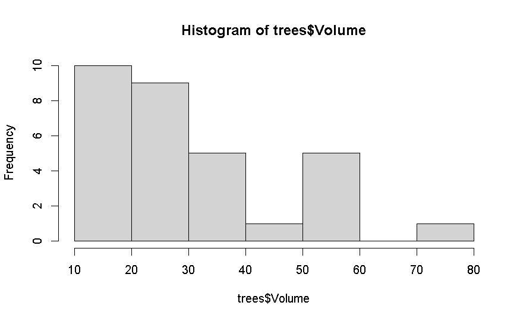

```r
hist(trees$Volume)
```

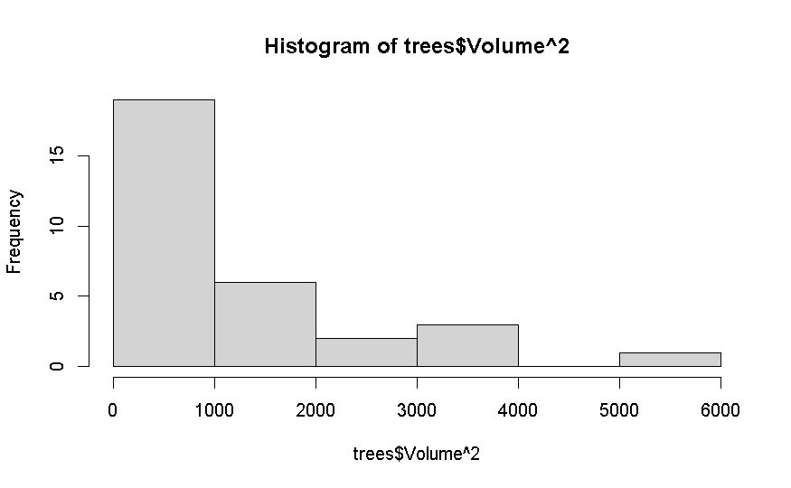

```r
hist(trees$Volume^2)
```

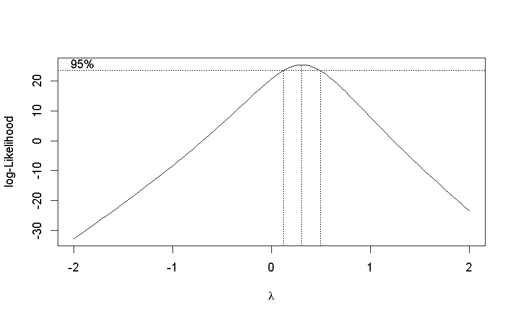

```r
#la regressione nel complesso non viene male, ma se volessimo essere "perfetti", proseguiamo e usiamo il boxcox per agire sul fatto che la distribuzione iniziale del volume degli alberi non era normale. Poi gli controllo i valori di lambda e ho zoommato il grafico tra 0 e 0.5.Così mi sono aiutato a trovare il valore a cui elevare y.
library(MASS)
?boxcox
bctrans <- boxcox(Volume ~ Height + Girth, data = trees)
```

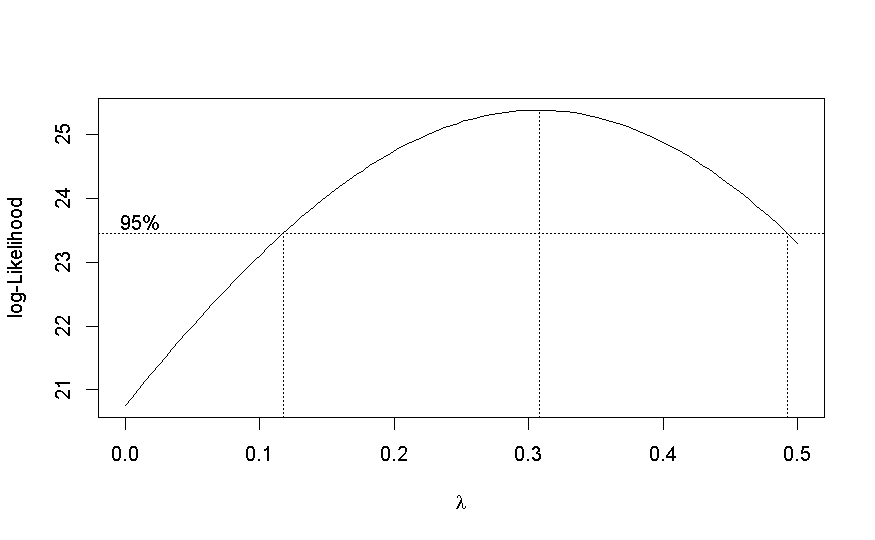

```r
bctrans <- boxcox(Volume ~ Height + Girth, data = trees,
                  lambda = seq(0, 0.5, length = 10))
```

```r
bctrans
```

[output not shown]

```r
which(bctrans$y==max(bctrans$y))  #dove si trova il picco
```

[output not shown]

```r
bctrans$x[62]#lambda è l'esponente a cui vado ad elevare il volume
```

[output not shown]

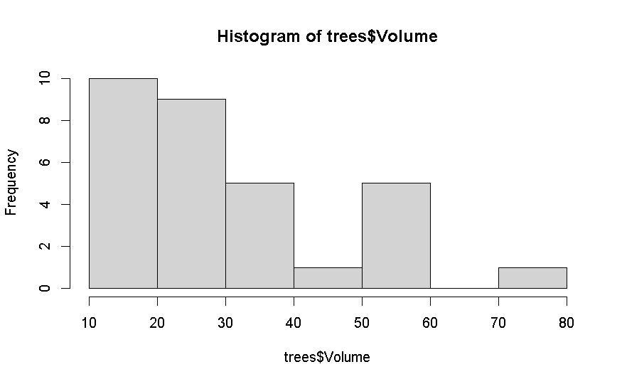

```r
hist(trees$Volume)
```

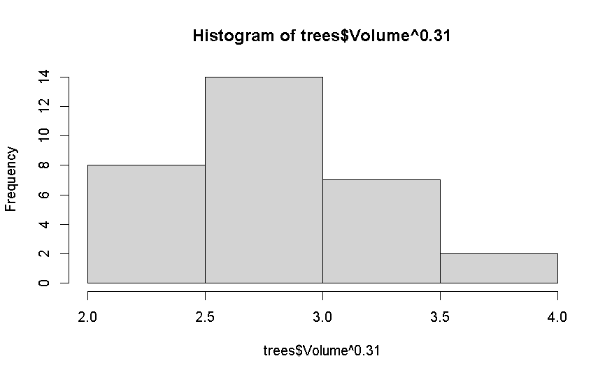

```r
hist(trees$Volume^0.31)
```

```r
max(bctrans$y)
```

```
[1] 25.37442
```

```r
library(dplyr)
risultati.bc <- data.frame(bctrans$y, bctrans$x)
head(risultati.bc)
```

[output not shown]

```r
arrange(risultati.bc, bctrans.y)
```

| bctrans.y | bctrans.x |
| --- | --- |
| 20.75262 | 0.000000000 |
| 20.88419 | 0.005050505 |
| 21.01463 | 0.010101010 |
| 21.14390 | 0.015151515 |
| 21.27197 | 0.020202020 |
| 21.39879 | 0.025252525 |
| 21.52433 | 0.030303030 |
| 21.64856 | 0.035353535 |
| 21.77142 | 0.040404040 |
| 21.89289 | 0.045454545 |

[output cut: 90 more lines]

```r
trees %>%
  mutate(Volume.bc=Volume^0.31) ->trees.bc
mod.new<-lm(Volume.bc ~ Height + Girth, data = trees.bc)
summary(mod.new)
```

```
Call:
lm(formula = Volume.bc ~ Height + Girth, data = trees.bc)

Residuals:
     Min       1Q   Median       3Q      Max
-0.13566 -0.04397 -0.00557  0.05948  0.11655

Coefficients:
            Estimate Std. Error t value Pr(>|t|)
(Intercept) 0.117028   0.158601   0.738    0.467
Height      0.012559   0.002390   5.256 1.38e-05 ***
Girth       0.130015   0.004852  26.796  < 2e-16 ***
---
Signif. codes:  0 ‘***’ 0.001 ‘**’ 0.01 ‘*’ 0.05 ‘.’ 0.1 ‘ ’ 1

Residual standard error: 0.07127 on 28 degrees of freedom
Multiple R-squared:  0.9776,    Adjusted R-squared:  0.976
F-statistic: 610.6 on 2 and 28 DF,  p-value: < 2.2e-16
```

```r
#vado a creare questo nuovo modello
```